# Anatomía de un colapso financiero evitable en la Caja Fiscal (2015–2025)

dmeza.py@gmail.com

02/02/2026

# Introducción: La Ceguera Sistémica ante la Inevitabilidad Matemática

El presente informe constituye un análisis exhaustivo y crítico de la evolución financiera de la **Caja Fiscal** (Administración Central) de la República del Paraguay. Basándose en la serie histórica de informes financieros oficiales (2015-2024), este documento demuestra que la crisis actual de insolvencia y falta de liquidez no fue producto de un choque externo impredecible, sino el desenlace de un **descalce estructural persistente** documentado minuciosamente por el propio Estado.

A lo largo de una década, los balances oficiales emitieron alertas inequívocas sobre la **disminución del valor del patrimonio**. Sin embargo, la respuesta institucional se limitó a una gestión de flujos de corto plazo, ignorando las proyecciones actuariales que señalaban la necesidad de reformas paramétricas urgentes. La falta de previsión ha convertido un desajuste contable en una crisis sistémica que hoy consume masivamente los Recursos del Tesoro, comprometiendo el financiamiento de otros servicios básicos.

# Marco Analítico y Métricas de Tensión Financiera

Sea para cada año (t):

## Identidad del Financiamiento Requerido

Este indicador mide el monto neto que debe ser cubierto con recursos extraprevisionales (Rentas Generales, deuda o instrumentos equivalentes).

# Datos estructurados (hitos explícitos)

## Tabla 1. Hitos cuantitativos y señales críticas

Tabla 1. Hitos cuantitativos explícitos y señales de estrés (valores citados en el cuerpo del informe).

| 2015 | 2.028.696 | 3.188.398 | 1.159.702 | 1,57 | 57,2% | -1.278.971 | NA | NA | NA | NA |
| --- | --- | --- | --- | --- | --- | --- | --- | --- | --- | --- |
| 2019 | NA | 4.802.376 | NA | NA | NA | -2.361.144 | NA | NA | NA | NA |
| 2022 | NA | 6.389.377 | NA | NA | NA | NA | NA | NA | NA | NA |
| 2023 | 3.240.244 | 9.608.636 | 6.368.392 | 2,97 | 196,5% | NA | 7.776.037 | 104,19% | 2.412.110 | -59,67% |
| 2024 | NA | NA | NA | NA | NA | NA | NA | NA | 0 | NA |

# Complemento 1. Semáforo técnico del déficit relativo (Δ/I)

Tabla 2. Semáforo del déficit relativo (Δ/I). Se reportan solo años con información simultánea de I_t y G_t.

| 2015 | 57,2% | Alto |
| --- | --- | --- |
| 2023 | 196,5% | Crítico |

## Figura 0. Perfil del déficit relativo (Δ/I)

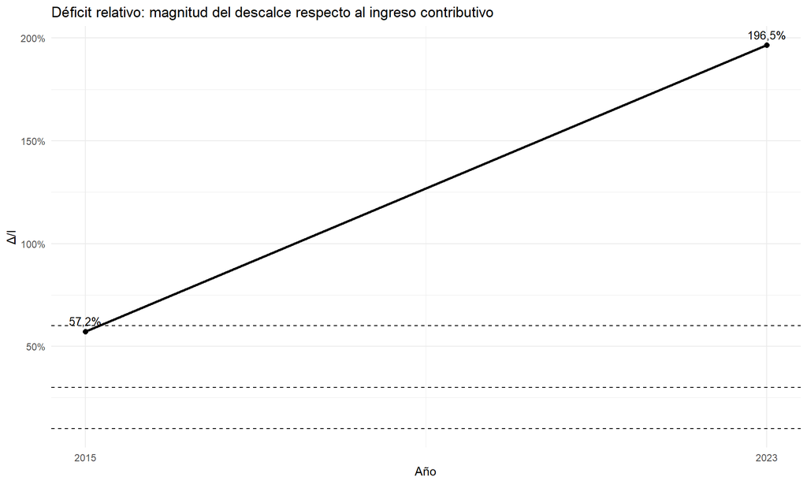

Figura 0. Déficit relativo (Δ/I) por año (solo años con I_t y G_t explícitos).

# Complemento 2. Módulo de consistencia interna (auto-auditoría de R_t)

Para robustecer la trazabilidad del documento, se implementa un control que compara:

- (R_t) **calculado** a partir de (I_t) y (G_t), contra
- (R_t) **reportado** narrativamente (si aplica).

El control se considera satisfactorio si la diferencia absoluta (|R^{calc}_t - R^{rep}_t|) es menor o igual a `TOL_RT`.

Tabla 3. Control de consistencia de R_t (reportado vs calculado). Criterio: |Dif| ≤ tolerancia.

| 2015 | 2.028.696 | 3.188.398 | 1,5716 | 1,5700 | 0,0016 | OK |
| --- | --- | --- | --- | --- | --- | --- |

## Figura 0b. Comparación de R_t reportado vs calculado

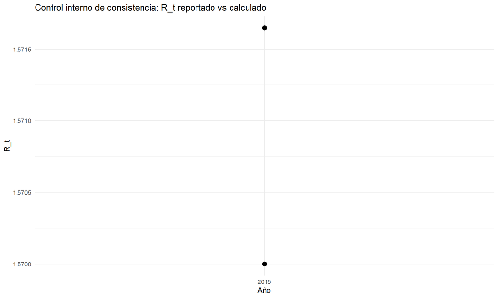

Figura 0b. Comparación de R_t reportado frente a R_t calculado (solo años con dato reportado).

# Relato Cronológico del Deterioro Patrimonial (2015–2024)

## La Fase de Gestación y Alertas Ignoradas (2015–2017)

En **2015**, el informe financiero reportaba un resultado deficitario de **G. -1.278.971 millones**. El Ministerio definía técnicamente este saldo negativo como una pérdida directa de riqueza patrimonial.

- Dato sustentado: en 2015 las contribuciones sociales eran de **G. 2.028.696 millones**, mientras las prestaciones obligadas ascendían a **G. 3.188.398 millones**, con (R_{2015} = 1,57).

## La Fase de Profundización del Descalce (2018–2019)

Hacia **2019**, el gasto en jubilaciones y pensiones escalaba a **G. 4.802.376 millones**, y el déficit del ejercicio de la Administración Central se ubicaba en **G. -2.361.144 millones**.

## Shock de Pandemia y Exposición de la Rigidez (2020–2022)

La pandemia expuso rigideces de gasto. En **2022**, el gasto reportado ya alcanzaba **G. 6.389.377 millones**, confirmando que el problema no era transitorio.

## Fase Crítica: El Colapso de las Reservas y Liquidez (2023–2024)

En **2023**, se observa una ruptura de liquidez: la **deuda flotante** se incrementa **104,19%** hasta **G. 7.776.037 millones**, y las **reservas de revalúo** caen **59,67%**, quedando en **G. 2.412.110 millones**. La proyección referida para **2024** indica reservas **cero**.

# Figuras complementarias: visualización de la inevitabilidad matemática

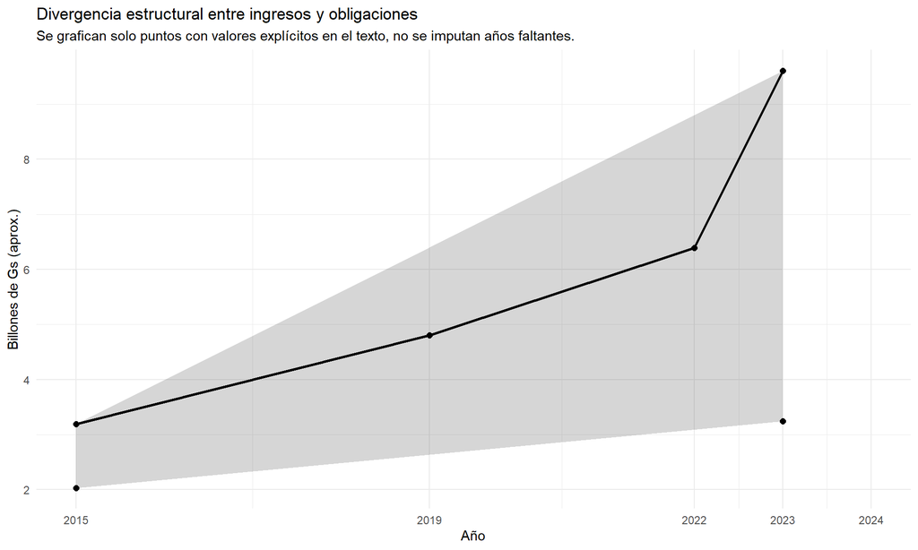

## Figura 2. Ratio de tensión (R_t) (umbral (=1))

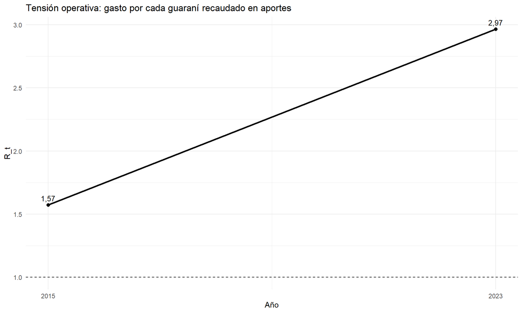

Figura 2. Ratio de tensión operativa R_t = G_t / I_t. Valores mayores a 1 implican dependencia de financiamiento fiscal.

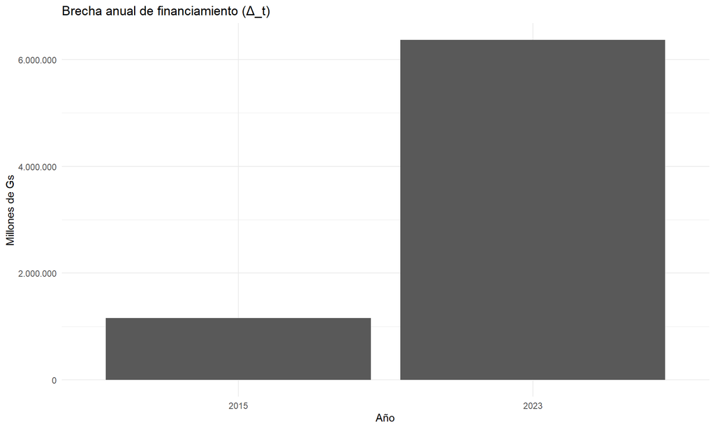

Figura 3. Brecha Δ_t = G_t - I_t (millones de Gs). Cuando Δ_t > 0, el monto representa financiamiento requerido para cumplir prestaciones.

# Radiografía de la Crisis por Sectores

El análisis por sectores (Población Abierta) demuestra que el descalce es asimétrico y está concentrado en regímenes con beneficios desproporcionados a sus aportes.

## Tabla 4. Desbalance actuarial sectorial y cobertura

Tabla 4. Indicadores actuariales por sector (Población Abierta). Cobertura expresa qué fracción de beneficios está respaldada por aportes en VP.

[output not shown]

## Figura 4. Déficit actuarial por sector (magnitud relativa)

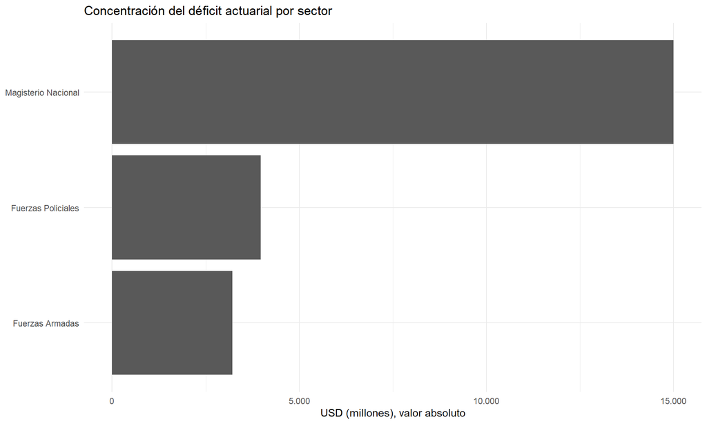

Figura 4. Déficit actuarial (USD, millones) por sector. Se grafica el valor absoluto para comparar magnitudes de presión fiscal implícita.

# La Inacción Administrativa vs. Evidencia Cuantitativa

Es imperativo resaltar que el Estado paraguayo poseía herramientas de diagnóstico y registro. A partir de 2015, se adoptó el manual **MEFP 2001 del FMI** para registrar operaciones que generaran obligaciones futuras. No obstante, no se ajustaron parámetros esenciales (edad de jubilación, años de aporte, tasa de aporte, tasa de reemplazo) en una magnitud consistente con la trayectoria del descalce.

## Tabla 5. Señales de estrés de liquidez y patrimonio (síntesis)

Tabla 5. Señales de estrés de liquidez y respaldo patrimonial (con valores explícitos citados en el texto).

| 2023 | 7.776.037 | 104,19% | 2.412.110 | -59,67% |
| --- | --- | --- | --- | --- |
| 2024 | NA | NA | 0 | NA |

# Conclusión: Un Desastre de Gestión Previsible

La crisis de la Caja Fiscal no es un accidente; es un **fracaso de gestión pública frente a evidencia cuantitativa persistente**.

1. **Sostenibilidad quebrada:** un (R_t>1) implica subsidio fiscal recurrente, por definición.
2. **Canibalización de reservas:** la caída de reservas de revalúo y la proyección a cero implican pérdida del colchón patrimonial.
3. **Ventana de reforma cerrada:** la postergación sistemática transforma un ajuste gradual posible en un ajuste concentrado y socialmente costoso.

# Referencias Bibliográficas (APA)

- Ministerio de Economía y Finanzas de Paraguay. (2024). *Informe Financiero Ejercicio Fiscal 2024: Proyecciones y Balances Consolidados*. Asunción, Paraguay.
- Ministerio de Hacienda de Paraguay. (2015-2022). *Informes Financieros Anuales: Tomos I, II, III y IV*. Asunción, Paraguay.
- Fondo Monetario Internacional (FMI). (2023). *Informe País N° 24/1: Revisión del Instrumento de Coordinación de Políticas*.
- Ministerio de Economía y Finanzas. (2024). *Serie Histórica de Evolución del Gasto y Saldo de la Caja Fiscal (2011-2025)*.